# Reliability Analyses NHB2

Youssef Amin and Angelika Stefan

## Load packages

```r
library(Bayesrel)
```

## Read in data

```r
nhb2 <- read.csv('../../data/nhb2_processed.csv')
```

## Compute scale reliability scores

The main confirmatory hypotheses that are tested in the second study involve the following scales:

- Composite political orientation
- Mean intergroup bias
- Ingroup norms
- Moral foundations
- Need for cognitive control

### Composite political orientation

The composite political orientation scale is computed as the average of the social and economic conservativeness scale (SEC) as well as three items measuring economic, social, and political orientation. We compute Cronbach’s alpha for the SEC and the composite political orientation scale in the frequentist and Bayesian paradigm.

```r
# SEC reliability
strel(nhb2[,c("RC_SECS_1", paste0("SECS_", 2:4), "RC_SECS_5", paste0("SECS_", 6:12))], estimates = "alpha")
```

```
## Call:
## strel(data = nhb2[, c("RC_SECS_1", paste0("SECS_", 2:4), "RC_SECS_5",
##     paste0("SECS_", 6:12))], estimates = "alpha")
##
## Estimates of Single-Test Reliability Measures:
##
##             point est  95 % CI lower  95% CI upper
## Bayes_alpha   0.89449        0.88503       0.90434
## freq_alpha    0.89484        0.88502       0.90403
```

```r
# Composite political orientation scale
strel(nhb2[, c("z_mean_SECS", "z_EconOrient", "z_SocOrient", "z_PolOrient")], estimates = "alpha")
```

```
## Call:
## strel(data = nhb2[, c("z_mean_SECS", "z_EconOrient", "z_SocOrient",
##     "z_PolOrient")], estimates = "alpha")
##
## Estimates of Single-Test Reliability Measures:
##
##             point est  95 % CI lower  95% CI upper
## Bayes_alpha   0.94378        0.93737       0.94980
## freq_alpha    0.94381        0.93735       0.94971
```

Both scales show excellent internal consistency.

### Mean intergroup bias

The mean intergroup bias scale is composed of three variables:

- The difference in ingroup and outgroup evaluative trait ratings (each in itself a rating scale with 6 items)
- The difference in points allocated to ingroup and outgroup in the Tajfel matrices
- The difference in ingroup and outgroup identification

We compute Cronbach’s alpha for the trait rating scales and the intergroup bias scale in the frequentist and Bayesian paradigm.

```r
# Ingroup Evaluative Traits
strel(nhb2[, c("RC_InTraits_1","InTraits_2","InTraits_3", "RC_InTraits_4","InTraits_5","RC_InTraits_6")], estimates = "alpha")
```

```
## Call:
## strel(data = nhb2[, c("RC_InTraits_1", "InTraits_2", "InTraits_3",
##     "RC_InTraits_4", "InTraits_5", "RC_InTraits_6")], estimates = "alpha")
##
## Estimates of Single-Test Reliability Measures:
##
##             point est  95 % CI lower  95% CI upper
## Bayes_alpha   0.88370        0.87085       0.89592
## freq_alpha    0.88402        0.87105       0.89590
```

```r
# Outgroup Evaluative Traits
strel(nhb2[, c("RC_OutTraits_1","OutTraits_2","OutTraits_3", "RC_OutTraits_4","OutTraits_5","RC_OutTraits_6")], estimates = "alpha")
```

```
## Call:
## strel(data = nhb2[, c("RC_OutTraits_1", "OutTraits_2", "OutTraits_3",
##     "RC_OutTraits_4", "OutTraits_5", "RC_OutTraits_6")], estimates = "alpha")
##
## Estimates of Single-Test Reliability Measures:
##
##             point est  95 % CI lower  95% CI upper
## Bayes_alpha   0.84644        0.82809       0.86392
## freq_alpha    0.82962        0.81088       0.84682
```

Both the ingroup and outgroup evaluative trait measure have excellent internal consistency.

```r
# Mean intergroup bias
strel(nhb2[, c("z_total_ingroup_minus_outgroup_points", "z_ingroup_minus_outgroup_traits_positive", "z_ingroup_minus_outgroup_identify")], estimates = "alpha")
```

```
## Call:
## strel(data = nhb2[, c("z_total_ingroup_minus_outgroup_points",
##     "z_ingroup_minus_outgroup_traits_positive", "z_ingroup_minus_outgroup_identify")],
##     estimates = "alpha")
##
## Estimates of Single-Test Reliability Measures:
##
##             point est  95 % CI lower  95% CI upper
## Bayes_alpha   0.60420        0.56189       0.65083
## freq_alpha    0.60577        0.56000       0.64753
```

Same as in Study 1, the mean intergroup bias measure has inadequate internal consistency ($\alpha$ << .70). We will therefore compute all analyses with the three variables separately as exploratory analyses. Below is a correlation plot showing that a lack of variance in the variables is not the reason for the low correlations

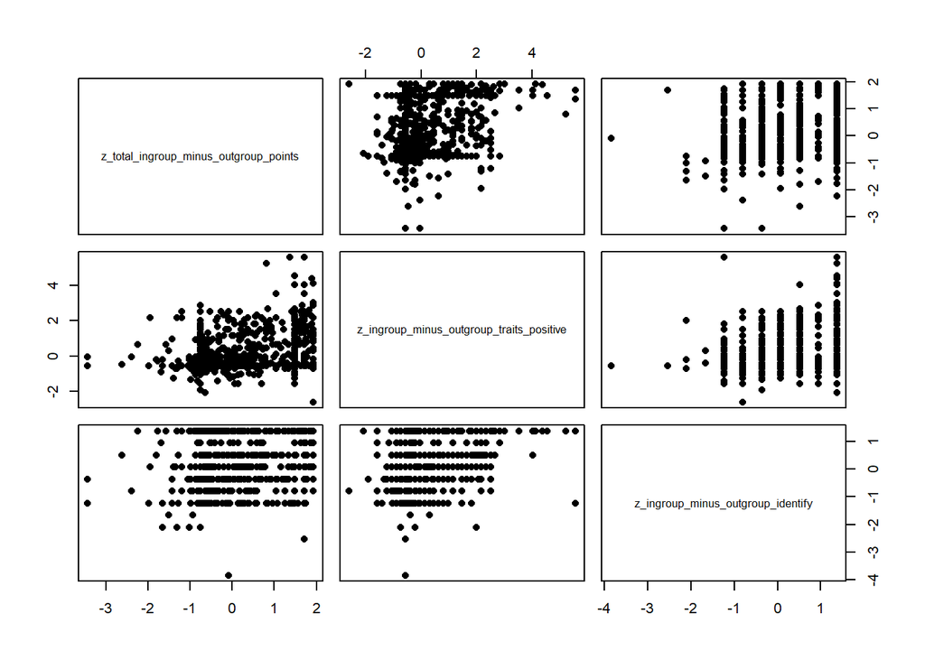

```r
plot(nhb2[, c("z_total_ingroup_minus_outgroup_points", "z_ingroup_minus_outgroup_traits_positive", "z_ingroup_minus_outgroup_identify")], pch=16)
```

### Ingroup norms

The perceived norms scale consists of four items.

```r
strel(nhb2[, c("norms_admire_accept", "norms_admire_express", "norms_amer_accept", "norms_amer_express")], estimates = "alpha")
```

```
## Call:
## strel(data = nhb2[, c("norms_admire_accept", "norms_admire_express",
##     "norms_amer_accept", "norms_amer_express")], estimates = "alpha")
##
## Estimates of Single-Test Reliability Measures:
##
##             point est  95 % CI lower  95% CI upper
## Bayes_alpha   0.71312        0.68096       0.74506
## freq_alpha    0.71360        0.67987       0.74431
```

The perceived norms scale has acceptable internal consistency ($\alpha$ > .70).

### Moral foundations

We used three subscales from the Moral Foundations questionnaire: Loyalty, Respect for Authority, Purity. We compute the internal consistency of all three subscales as well as of the overall scale.

```r
# Loyalty subscale
strel(nhb2[, c("mf_pt1_1", "mf_pt1_4", "mf_pt1_7", "mf_pt2_1", "mf_pt2_4", "mf_pt2_7")], estimates = "alpha")
```

```
## Call:
## strel(data = nhb2[, c("mf_pt1_1", "mf_pt1_4", "mf_pt1_7", "mf_pt2_1",
##     "mf_pt2_4", "mf_pt2_7")], estimates = "alpha")
##
## Estimates of Single-Test Reliability Measures:
##
##             point est  95 % CI lower  95% CI upper
## Bayes_alpha   0.79179        0.76837       0.81058
## freq_alpha    0.79212        0.77045       0.81214
```

```r
# Authority subscale
strel(nhb2[, c("mf_pt1_2", "mf_pt1_5", "mf_pt1_8", "mf_pt2_2", "mf_pt2_5", "mf_pt2_8")], estimates = "alpha")
```

```
## Call:
## strel(data = nhb2[, c("mf_pt1_2", "mf_pt1_5", "mf_pt1_8", "mf_pt2_2",
##     "mf_pt2_5", "mf_pt2_8")], estimates = "alpha")
##
## Estimates of Single-Test Reliability Measures:
##
##             point est  95 % CI lower  95% CI upper
## Bayes_alpha   0.80485        0.78445       0.82336
## freq_alpha    0.80516        0.78531       0.82355
```

```r
# Purity subscale
strel(nhb2[, c("mf_pt1_3", "mf_pt1_6", "mf_pt1_9", "mf_pt2_3", "mf_pt2_6", "mf_pt2_9")], estimates = "alpha")
```

```
## Call:
## strel(data = nhb2[, c("mf_pt1_3", "mf_pt1_6", "mf_pt1_9", "mf_pt2_3",
##     "mf_pt2_6", "mf_pt2_9")], estimates = "alpha")
##
## Estimates of Single-Test Reliability Measures:
##
##             point est  95 % CI lower  95% CI upper
## Bayes_alpha   0.86215        0.84828       0.87617
## freq_alpha    0.86265        0.84841       0.87581
```

```r
# Full scale
strel(nhb2[, c("mf_pt1_1", "mf_pt1_4", "mf_pt1_7", "mf_pt2_1", "mf_pt2_4", "mf_pt2_7",
               "mf_pt1_2", "mf_pt1_5", "mf_pt1_8", "mf_pt2_2", "mf_pt2_5", "mf_pt2_8",
               "mf_pt1_3", "mf_pt1_6", "mf_pt1_9", "mf_pt2_3", "mf_pt2_6", "mf_pt2_9")], estimates = "alpha")
```

```
## Call:
## strel(data = nhb2[, c("mf_pt1_1", "mf_pt1_4", "mf_pt1_7", "mf_pt2_1",
##     "mf_pt2_4", "mf_pt2_7", "mf_pt1_2", "mf_pt1_5", "mf_pt1_8",
##     "mf_pt2_2", "mf_pt2_5", "mf_pt2_8", "mf_pt1_3", "mf_pt1_6",
##     "mf_pt1_9", "mf_pt2_3", "mf_pt2_6", "mf_pt2_9")], estimates = "alpha")
##
## Estimates of Single-Test Reliability Measures:
##
##             point est  95 % CI lower  95% CI upper
## Bayes_alpha   0.92106        0.91395       0.92856
## freq_alpha    0.92116        0.91366       0.92816
```

All subscales and the full scale have excellent internal consistency.

### Need for cognitive control

The Need for Cognitive Control scale consists of 15 items.

```r
strel(nhb2[, grepl("NFCC_", colnames(nhb2))], estimates = "alpha")
```

```
## Call:
## strel(data = nhb2[, grepl("NFCC_", colnames(nhb2))], estimates = "alpha")
##
## Estimates of Single-Test Reliability Measures:
##
##             point est  95 % CI lower  95% CI upper
## Bayes_alpha   0.88282        0.87219       0.89381
## freq_alpha    0.88324        0.87195       0.89376
```

The scale has excellent internal consistency.

## System information (for reproducibility)

```r
Sys.info()[1:3]
```

```
##       sysname       release       version
##     "Windows"      "10 x64" "build 22631"
```